# R Notebook

Now, we have to install all of these required packages.

```r
install.packages("xgboost")
install.packages("pRoc")
```

Let’s get stock data for Facebook. So the getSymbols function automatically downloaded daily data going all the way back to when Facebook just IPOs.

```r
library(quantmod)
getSymbols(c("FB"))
```

```
[1] "FB"
```

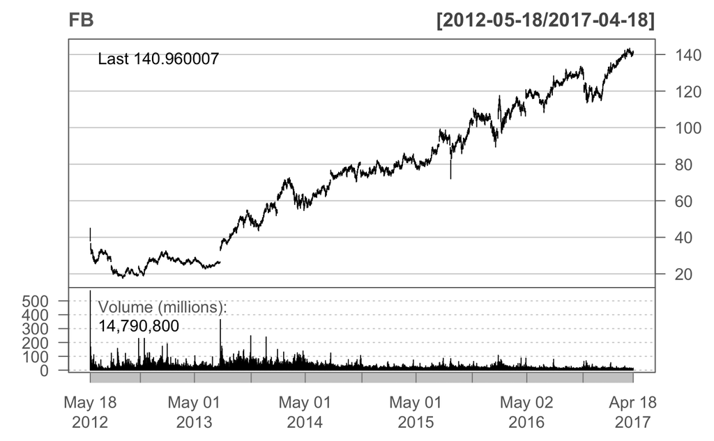

```r
barChart(FB,theme='white.mono',bar.type='hlc')
```

Let’s see how easy it is to display a full stock chart (S&P 500) with indicators.

Quantmod uses Yahoo to get it’s financial data. In the following example ^GSPC represents the S&P 500 Index.

chartSeries - is straightforward and will plot whatever shybol has been downloaded to memory using ‘getSymbols’

addBBands - will plot Bollinger Bands around price series.

```r
getSymbols(c("^GSPC"))
```

```
[1] "GSPC"
```

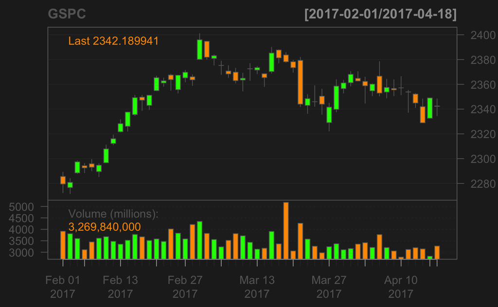

```r
chartSeries(GSPC,subset='last 3 months')
```

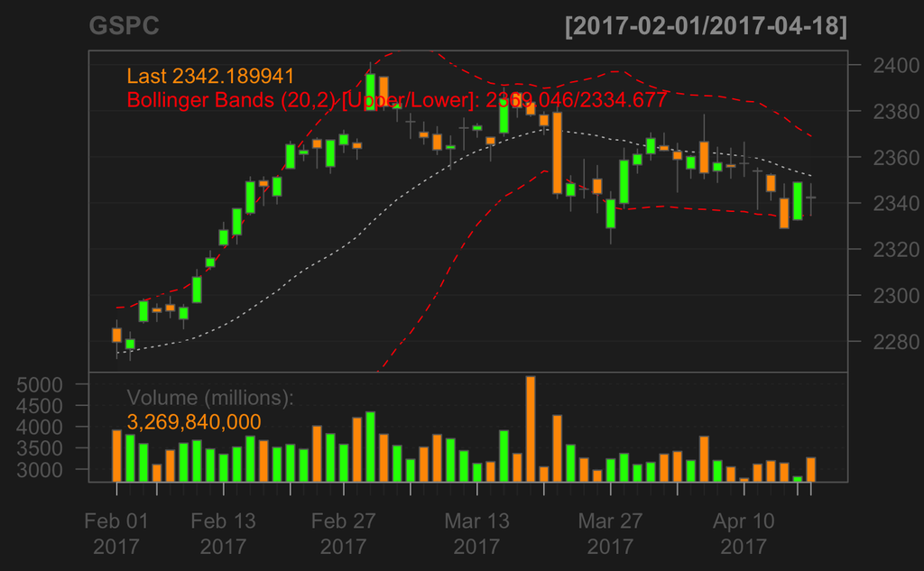

```r
addBBands(n=20,sd=2,ma="SMA",draw='bands',on=-1)
```

Now, we will moving deeper into analysis part.

```r
Nasdaq100_Symbols <- c('AAPL', 'AMZN')
stocks <- getSymbols(Nasdaq100_Symbols)
```

Since the stock data is separate for each stock I will combine them in a matrix named df, and also combine the column names in a separate list as this will be useful in understanding the data

```r
cols = list()
df <- matrix(data = NA, ncol = 6*length(stocks), nrow = dim(get(stocks[1]))[1])
for(i in 1:length(stocks)){
  in1 <- 6*(i-1)+1
  in2 <- 6*i
  df[,in1:in2] <- get(stocks[i])
  cols <- c(cols, colnames(get(stocks[i])))
}
colnames(df) <- cols
```

Next row names are added and a separate column for the date is added, labelled, and the matrix is converted to a data frame

```r
rownames(df)<- as.character.Date(index(get(stocks[1])))
df.dates <- as.data.frame(cbind(as.character.Date(index(get(stocks[1]))), df))
colnames(df.dates)[1] <- 'Date'
head(df.dates)
```

|  | Date | AAPL.Open | AAPL.High | AAPL.Low | AAPL.Close | AAPL.Volume | AAPL.Adjusted | AMZN.Open | AMZN.High | AMZN.Low | AMZN.Close | AMZN.Volume | AMZN.Adjusted |
| --- | --- | --- | --- | --- | --- | --- | --- | --- | --- | --- | --- | --- | --- |
| 2007-01-03 | 2007-01-03 | 86.289999 | 86.579999 | 81.899999 | 83.800002 | 309579900 | 10.857091 | 38.68 | 39.060001 | 38.049999 | 38.700001 | 12405100 | 38.700001 |
| 2007-01-04 | 2007-01-04 | 84.050001 | 85.949998 | 83.820003 | 85.659998 | 211815100 | 11.098071 | 38.59 | 39.139999 | 38.259998 | 38.900002 | 6318400 | 38.900002 |
| 2007-01-05 | 2007-01-05 | 85.77 | 86.199997 | 84.400002 | 85.049997 | 208685400 | 11.019039 | 38.720001 | 38.790001 | 37.599998 | 38.369999 | 6619700 | 38.369999 |
| 2007-01-08 | 2007-01-08 | 85.959998 | 86.529998 | 85.280003 | 85.47 | 199276700 | 11.073455 | 38.220001 | 38.310001 | 37.169998 | 37.5 | 6783000 | 37.5 |
| 2007-01-09 | 2007-01-09 | 86.450003 | 92.979999 | 85.15 | 92.570003 | 837324600 | 11.993328 | 37.599998 | 38.060001 | 37.34 | 37.779999 | 5703000 | 37.779999 |
| 2007-01-10 | 2007-01-10 | 94.749999 | 97.800002 | 93.450003 | 96.999997 | 738220000 | 12.567276 | 37.490002 | 37.700001 | 37.07 | 37.150002 | 6527500 | 37.150002 |

Now we will tidy the data using dplyr and tidyr to only include the data we are interested in. Here we will just take the adjusted values.

```r
tidy_stocks <- as.data.frame(df.dates) %>%
  select(Date, contains('Adjusted')) %>%
  gather(Index, Price, -Date)
```

```
attributes are not identical across measure variables; they will be dropped
```

```r
head(tidy_stocks)
```

|  | Date | Index | Price |
| --- | --- | --- | --- |
| 1 | 2007-01-03 | AAPL.Adjusted | 10.857091 |
| 2 | 2007-01-04 | AAPL.Adjusted | 11.098071 |
| 3 | 2007-01-05 | AAPL.Adjusted | 11.019039 |
| 4 | 2007-01-08 | AAPL.Adjusted | 11.073455 |
| 5 | 2007-01-09 | AAPL.Adjusted | 11.993328 |
| 6 | 2007-01-10 | AAPL.Adjusted | 12.567276 |

Now, we will calculate the return on price. The reason why we use Log return is because: In general, while stock returns are not exactly normal, that is much closer to being the case. We use log return to assume the prices themselves are normal.

```r
stock_returns <- tidy_stocks %>%
  mutate(Simple.return = ifelse(lag(Index)==Index,(as.numeric(Price)-as.numeric(lag(Price)))/(as.numeric(lag(Price))),0)) %>%
  mutate(Log.return = ifelse(lag(Index)==Index,(log(as.numeric(Price))-log(as.numeric(lag(Price)))),0))
head(stock_returns)
```

|  | Date | Index | Price | Simple.return | Log.return |
| --- | --- | --- | --- | --- | --- |
| 1 | 2007-01-03 | AAPL.Adjusted | 10.857091 | NA | NA |
| 2 | 2007-01-04 | AAPL.Adjusted | 11.098071 | 0.022195632 | 0.021952895 |
| 3 | 2007-01-05 | AAPL.Adjusted | 11.019039 | -0.007121238 | -0.007146715 |
| 4 | 2007-01-08 | AAPL.Adjusted | 11.073455 | 0.004938362 | 0.004926208 |
| 5 | 2007-01-09 | AAPL.Adjusted | 11.993328 | 0.083070099 | 0.079799692 |
| 6 | 2007-01-10 | AAPL.Adjusted | 12.567276 | 0.047855608 | 0.046745798 |

Now, we will plot the stock price and return for Apple inc.

```r
library(ggplot2)
aapl_returns <- stock_returns %>% filter(grepl('AAPL',Index)) %>% select(-Index)
head(aapl_returns)
```

|  | Date | Price | Simple.return | Log.return |
| --- | --- | --- | --- | --- |
| 1 | 2007-01-03 | 10.857091 | NA | NA |
| 2 | 2007-01-04 | 11.098071 | 0.022195632 | 0.021952895 |
| 3 | 2007-01-05 | 11.019039 | -0.007121238 | -0.007146715 |
| 4 | 2007-01-08 | 11.073455 | 0.004938362 | 0.004926208 |
| 5 | 2007-01-09 | 11.993328 | 0.083070099 | 0.079799692 |
| 6 | 2007-01-10 | 12.567276 | 0.047855608 | 0.046745798 |

plot 1

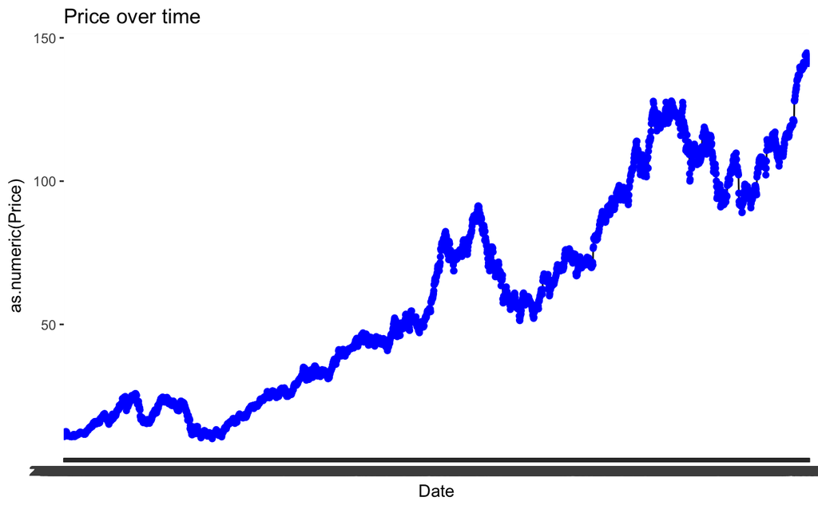

```r
plot1 <- ggplot(data = aapl_returns, aes(x = Date, y = as.numeric(Price), group = 1))+geom_line()+ geom_point(color="blue")
plot1 + ggtitle('Price over time')
```

plot 2

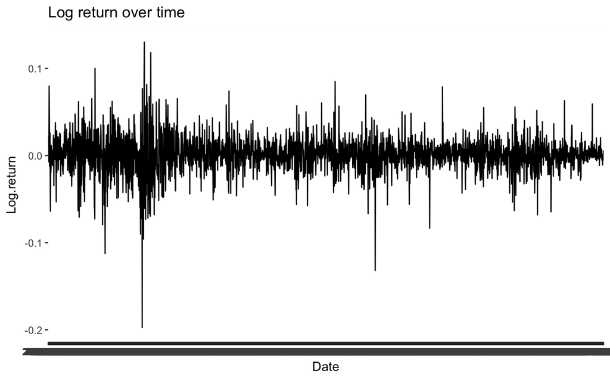

```r
plot2 <- ggplot(data = aapl_returns, aes(x = Date, y = Log.return, group = 1)) + geom_line()
plot2 + ggtitle('Log return over time')
```

plot 3

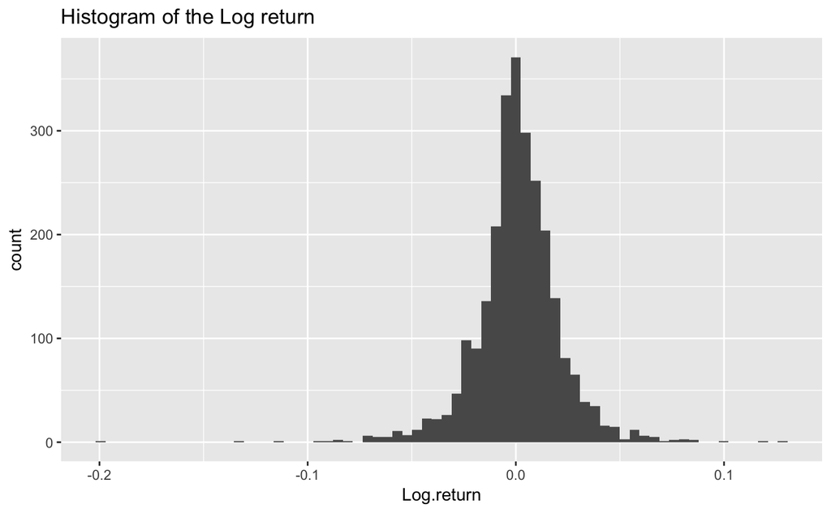

```r
plot3 <- ggplot(data = aapl_returns, aes(Log.return)) + geom_histogram(bins = 70)
plot3 + ggtitle('Histogram of the Log return')
```

```r
meanDist.daily <- mean(na.omit(aapl_returns$Log.return))
meanDist.yearly <- meanDist.daily * 252
meanDist.daily
```

```
[1] 0.0009904861
```

Let’s see its yearly return (252 trading days in a year)

```r
meanDist.yearly
```

```
[1] 0.2496025
```